## Shrub Density influences on Animals

The following is a review of shrubs that have been reported as benefactor species on local animal communities. Web of Science resources were queried using the following key terms.

"facil* density* shrub*”, “density* shrub* facilitate*” and “density* shrub* animal* facil*"

### Questions:

Is there evidence that shrub studies that reported facilitation of other plants or of animals influence measures of animal community composition?  
Is there are a relationship between animal abundance or richness and shrub or tree density? Is there a difference between the measures of animal community composition in studies that reported facilitation or not?

### Hypothesis:

Higher density of foundation species that have reported facilitation support higher densities or more rich animal communities.

### Predictions:

1. Reported benefactor plants better support animal communities.
2. Higher density of benefactor plants predict higher measures of animal community structure or composition.

### Good Figures (June 8th 2021)

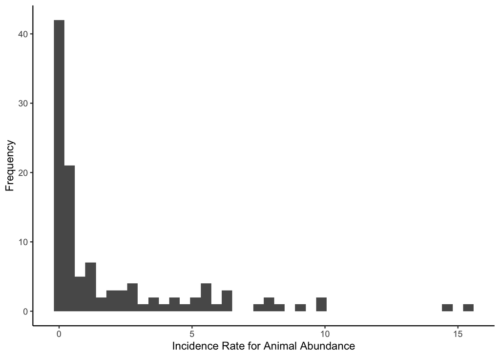

```r
ggplot(data = data_e1, aes(yi)) +
  geom_histogram(bins = 40) + labs(x = "Incidence Rate for Animal Abundance", y = "Frequency") + theme_classic()
```

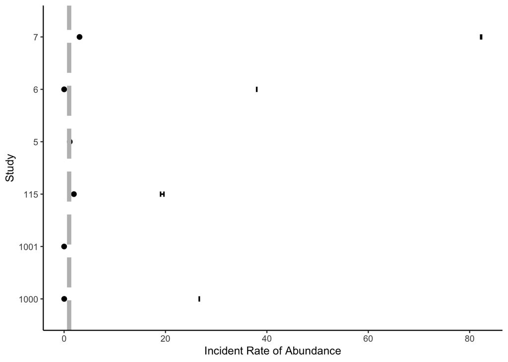

```r
ggplot(summary_data, aes(Study.ID, abundance_rate)) +
  geom_point(size =2) +
  geom_errorbar(aes(ymin = abundance - var_abundance, ymax = abundance + var_abundance), size= 0.7, width=0.1, position = position_dodge(width = 0.5)) +
  coord_flip() +
  geom_hline(yintercept = 1, colour="grey", linetype = "longdash", size = 2) +
  labs(x = "Study", y = "Incident Rate of Abundance") + theme_classic()
```

### Meta Models

```r
library(broom)
#x = density
#y = abundance
#With density
mod1.1 <- rma(yi = yi, sei = vi, method = "ML", test = "knha", control=list(stepadj=0.5), data = data_e1)
summary(mod1.1)
```

```
##
## Random-Effects Model (k = 113; tau^2 estimator: ML)
##
##    logLik   deviance        AIC        BIC       AICc
## -281.0118  1239.2260   566.0235   571.4783   566.1326
##
## tau^2 (estimated amount of total heterogeneity): 7.6846 (SE = 1.0334)
## tau (square root of estimated tau^2 value):      2.7721
## I^2 (total heterogeneity / total variability):   100.00%
## H^2 (total variability / sampling variability):  25834509573.18
##
## Test for Heterogeneity:
## Q(df = 112) = 1049029.0227, p-val < .0001
##
## Model Results:
##
## estimate      se    tval    pval   ci.lb   ci.ub
##   1.9008  0.2743  6.9287  <.0001  1.3572  2.4444  ***
##
## ---
## Signif. codes:  0 '***' 0.001 '**' 0.01 '*' 0.05 '.' 0.1 ' ' 1
```

```r
mod1.2 <- rma(yi = yi, sei = vi, method = "ML", mods = ~macrohabitat-1, test = "knha", control=list(stepadj=0.5), data = data_e1)
summary(mod1.2)
```

```
##
## Mixed-Effects Model (k = 113; tau^2 estimator: ML)
##
##    logLik   deviance        AIC        BIC       AICc
## -280.7982  1238.7988   567.5963   575.7785   567.8165
##
## tau^2 (estimated amount of residual heterogeneity):     7.6299 (SE = 1.0261)
## tau (square root of estimated tau^2 value):             2.7622
## I^2 (residual heterogeneity / unaccounted variability): 100.00%
## H^2 (unaccounted variability / sampling variability):   24746718787.32
##
## Test for Residual Heterogeneity:
## QE(df = 111) = 775272.6960, p-val < .0001
##
## Test of Moderators (coefficients 1:2):
## F(df1 = 2, df2 = 111) = 24.0660, p-val < .0001
##
## Model Results:
##
##                        estimate      se    tval    pval   ci.lb   ci.ub
## macrohabitatdesert       2.1345  0.4659  4.5815  <.0001  1.2113  3.0577  ***
## macrohabitatgrassland    1.7750  0.3407  5.2097  <.0001  1.0999  2.4501  ***
##
## ---
## Signif. codes:  0 '***' 0.001 '**' 0.01 '*' 0.05 '.' 0.1 ' ' 1
```

```r
m1.1 <- tidy(mod1.1)
m1.1
```

```
## # A tibble: 1 x 6
##   term    type    estimate std.error statistic  p.value
##   <chr>   <chr>      <dbl>     <dbl>     <dbl>    <dbl>
## 1 overall summary     1.90     0.274      6.93 2.84e-10
```

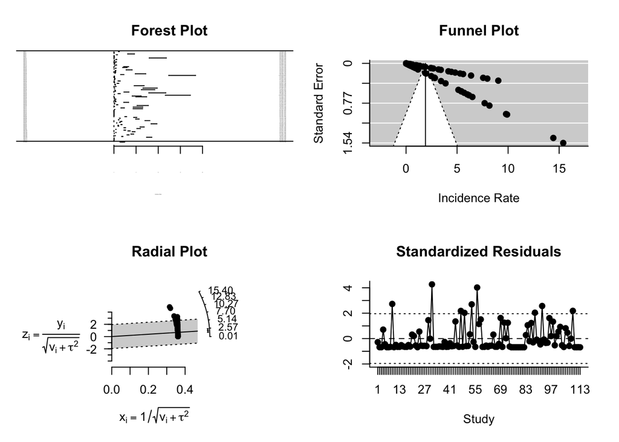

```r
plot(mod1.1)
```

###Weighted regression with all data

```r
gmodel <- lm(standardized.density ~ abundance, data=data_all, weights = n_days)
gmodel
```

```
##
## Call:
## lm(formula = standardized.density ~ abundance, data = data_all,
##     weights = n_days)
##
## Coefficients:
## (Intercept)    abundance
##     4851.00        43.49
```

```r
summary(gmodel)
```

```
##
## Call:
## lm(formula = standardized.density ~ abundance, data = data_all,
##     weights = n_days)
##
## Weighted Residuals:
##     Min      1Q  Median      3Q     Max
## -197129  -31209  -16262  -14951  351038
##
## Coefficients:
##             Estimate Std. Error t value Pr(>|t|)
## (Intercept)  4851.00     990.55   4.897 3.33e-06 ***
## abundance      43.49      25.08   1.734   0.0856 .
## ---
## Signif. codes:  0 '***' 0.001 '**' 0.01 '*' 0.05 '.' 0.1 ' ' 1
##
## Residual standard error: 66830 on 111 degrees of freedom
## Multiple R-squared:  0.02639,    Adjusted R-squared:  0.01762
## F-statistic: 3.008 on 1 and 111 DF,  p-value: 0.08562
```

### Fig1 with Line

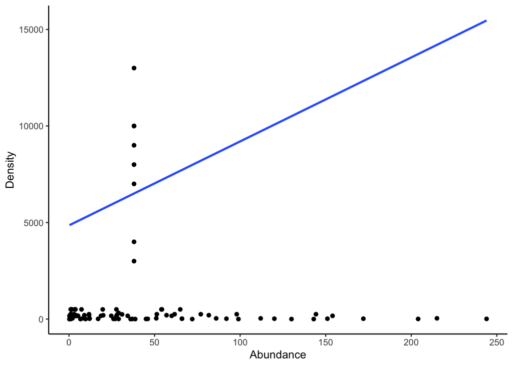

```r
ggplot(data = data_e1, aes(abundance, standardized.density)) +
  geom_point() +
  geom_smooth(method = "lm", mapping = aes(weight = n_days), se = F) + labs(x = "Abundance", y = "Density") + theme_classic()
```

### Fig1 With Curve

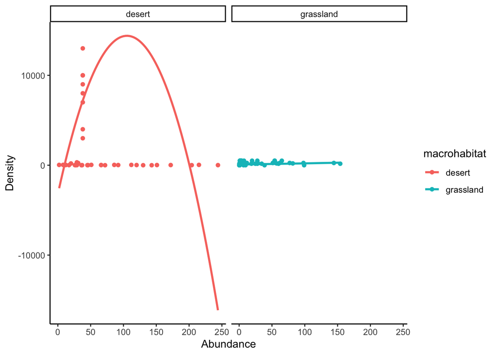

```r
fig1 <- ggplot(data = data_e1, aes(abundance, standardized.density, color = macrohabitat)) +
  geom_point() +
  geom_smooth(method = "lm", formula = y~x +I(x^2), mapping = aes(weight = n_days), se = F) + labs(x = "Abundance", y = "Density") + theme_classic() + facet_wrap(~macrohabitat)
fig1
```

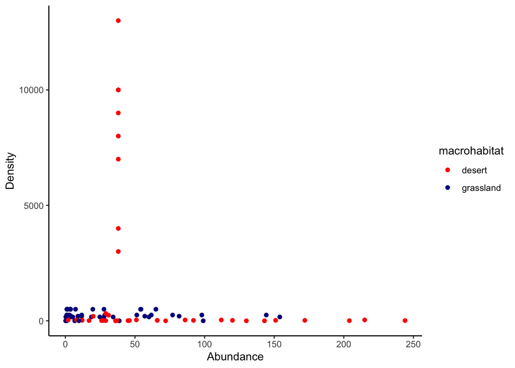

```r
color_points <- ggplot(data = data_e1, aes(abundance, standardized.density, color = macrohabitat)) +
  geom_point() + scale_color_manual(values = c("desert" = "red", "grassland" = "dark blue"))
color_points + theme(legend.title = element_blank()) + labs(x = "Abundance", y = "Density") +theme_classic()
```

```r
model1 <- lm(standardized.density ~ abundance, data=data_all)
summary(model1)
```

```
##
## Call:
## lm(formula = standardized.density ~ abundance, data = data_all)
##
## Residuals:
##     Min      1Q  Median      3Q     Max
##  -742.1  -682.4  -563.8  -480.3 12273.8
##
## Coefficients:
##             Estimate Std. Error t value Pr(>|t|)
## (Intercept) 742.2721   254.0139   2.922  0.00421 **
## abundance    -0.4242     4.1289  -0.103  0.91835
## ---
## Signif. codes:  0 '***' 0.001 '**' 0.01 '*' 0.05 '.' 0.1 ' ' 1
##
## Residual standard error: 2193 on 111 degrees of freedom
## Multiple R-squared:  9.509e-05,  Adjusted R-squared:  -0.008913
## F-statistic: 0.01056 on 1 and 111 DF,  p-value: 0.9184
```

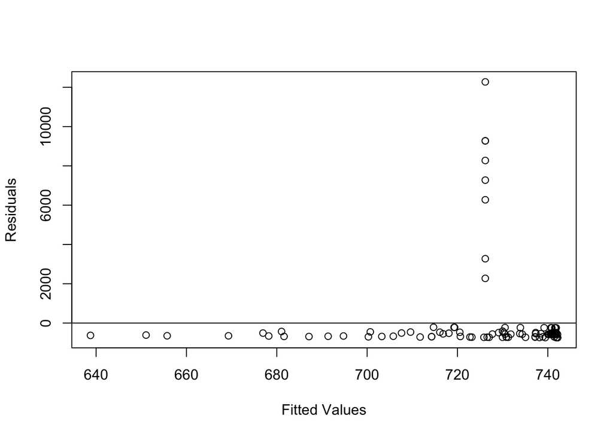

```
## integer(0)
```

```r
plot(fitted(model1), resid(model1), xlab='Fitted Values', ylab='Residuals') + abline(0,0)
```

```r
library(lmtest)
bptest(model1)
```

```
##
##  studentized Breusch-Pagan test
##
## data:  model1
## BP = 0.012607, df = 1, p-value = 0.9106
```

```r
wt <- 1 / lm(abs(model1$residuals) ~ model1$fitted.values)$fitted.values^2
wls_model <- lm(standardized.density ~ abundance, data = data_all, weights=wt)
summary(wls_model)
```

```
##
## Call:
## lm(formula = standardized.density ~ abundance, data = data_all,
##     weights = wt)
##
## Weighted Residuals:
##     Min      1Q  Median      3Q     Max
## -0.7073 -0.6890 -0.5400 -0.4571 11.8927
##
## Coefficients:
##             Estimate Std. Error t value Pr(>|t|)
## (Intercept) 705.8472   250.4437   2.818  0.00572 **
## abundance     0.6203     4.4588   0.139  0.88961
## ---
## Signif. codes:  0 '***' 0.001 '**' 0.01 '*' 0.05 '.' 0.1 ' ' 1
##
## Residual standard error: 2.125 on 111 degrees of freedom
## Multiple R-squared:  0.0001743,  Adjusted R-squared:  -0.008833
## F-statistic: 0.01935 on 1 and 111 DF,  p-value: 0.8896
```

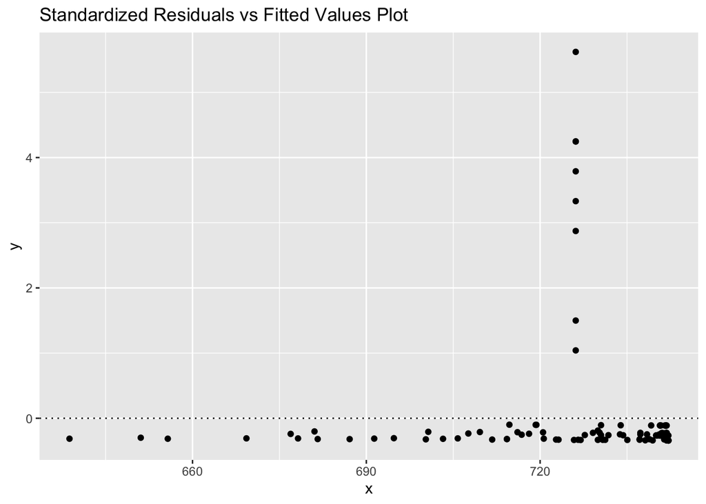

```r
data.frame(y = rstandard(model1),
           x = model1$fitted.values) %>%
  ggplot(aes(x = x, y = y)) +
  geom_point() +
  geom_hline(yintercept = 0, linetype = "dotted") +
  labs(title = "Standardized Residuals vs Fitted Values Plot")
```

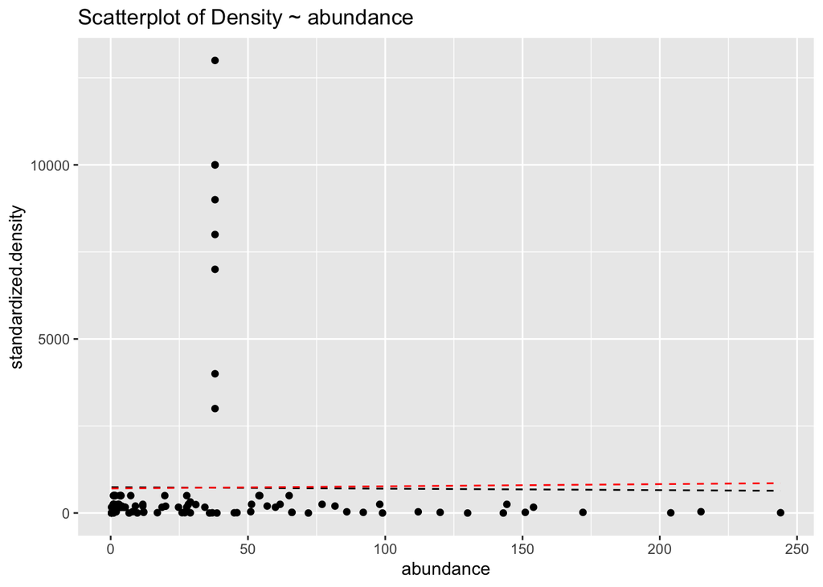

```r
ggplot(data = data_all, aes(y = standardized.density, x = abundance)) +
  geom_point() +
  geom_smooth(method = lm, se = FALSE,
              color = "black",
              size = 0.5,
              linetype = "dashed") +
  geom_smooth(method = lm, se = FALSE,
              aes(weight = wt),
              color = "red",
              size = 0.5,
              linetype = "dashed") +
  labs(title = "Scatterplot of Density ~ abundance")
```

###Trying to do regressions with summary data

```r
cmodel <- lm(density ~ abundance_rate, data=summary_data, weights = )
cmodel
```

[output not shown]

```r
summary(cmodel)
```

```
##
## Call:
## lm(formula = density ~ abundance_rate, data = summary_data)
##
## Residuals:
##       1       2       3       4       5       6
## -1308.0  5552.8   650.8  -262.7 -2183.8 -2449.0
##
## Coefficients:
##                Estimate Std. Error t value Pr(>|t|)
## (Intercept)        2460       1808   1.361    0.245
## abundance_rate    -1016       1171  -0.867    0.435
##
## Residual standard error: 3309 on 4 degrees of freedom
## Multiple R-squared:  0.1582, Adjusted R-squared:  -0.05221
## F-statistic: 0.7519 on 1 and 4 DF,  p-value: 0.4348
```

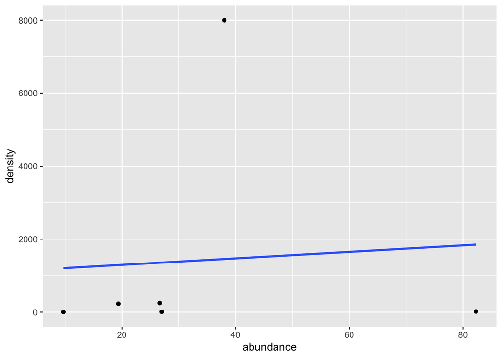

```r
ggplot(data = summary_data, aes(abundance, density)) +
  geom_point() +
  geom_smooth(method = "lm", se = FALSE)
```

```r
model <- lm(density ~ abundance, data=data_e1)
summary(model)
```

```
##
## Call:
## lm(formula = density ~ abundance, data = data_e1)
##
## Residuals:
##     Min      1Q  Median      3Q     Max
## -1836.7 -1469.3  -141.3   669.9  3776.7
##
## Coefficients:
##             Estimate Std. Error t value Pr(>|t|)
## (Intercept) 1839.576    181.629  10.128  < 2e-16 ***
## abundance     -9.481      2.952  -3.211  0.00173 **
## ---
## Signif. codes:  0 '***' 0.001 '**' 0.01 '*' 0.05 '.' 0.1 ' ' 1
##
## Residual standard error: 1568 on 111 degrees of freedom
## Multiple R-squared:  0.08502,    Adjusted R-squared:  0.07677
## F-statistic: 10.31 on 1 and 111 DF,  p-value: 0.001728
```

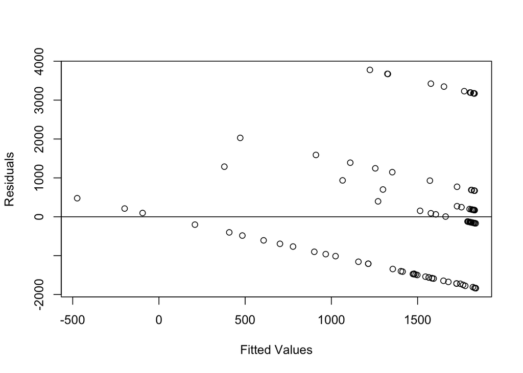

```
## integer(0)
```

```r
plot(fitted(model), resid(model), xlab='Fitted Values', ylab='Residuals') + abline(0,0)
```

```r
library(lmtest)
bptest(model)
```

```
##
##  studentized Breusch-Pagan test
##
## data:  model
## BP = 1.6003, df = 1, p-value = 0.2059
```

```r
wt <- 1 / lm(abs(model$residuals) ~ model$fitted.values)$fitted.values^2
wls_model <- lm(density ~ abundance, data = data_e1, weights=wt)
summary(wls_model)
```

```
##
## Call:
## lm(formula = density ~ abundance, data = data_e1, weights = wt)
##
## Weighted Residuals:
##     Min      1Q  Median      3Q     Max
## -1.4650 -1.2501 -0.0978  0.5592  3.3273
##
## Coefficients:
##             Estimate Std. Error t value Pr(>|t|)
## (Intercept) 1817.007    182.458   9.958  < 2e-16 ***
## abundance     -8.885      2.464  -3.606 0.000467 ***
## ---
## Signif. codes:  0 '***' 0.001 '**' 0.01 '*' 0.05 '.' 0.1 ' ' 1
##
## Residual standard error: 1.318 on 111 degrees of freedom
## Multiple R-squared:  0.1049, Adjusted R-squared:  0.09682
## F-statistic: 13.01 on 1 and 111 DF,  p-value: 0.0004666
```

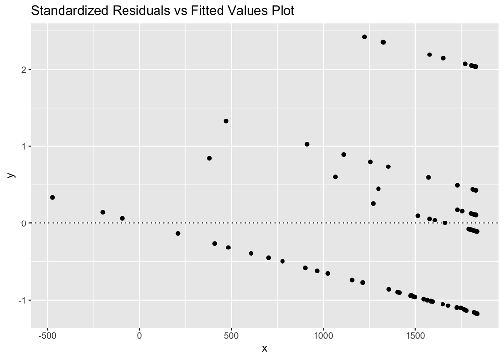

```r
data.frame(y = rstandard(model),
           x = model$fitted.values) %>%
  ggplot(aes(x = x, y = y)) +
  geom_point() +
  geom_hline(yintercept = 0, linetype = "dotted") +
  labs(title = "Standardized Residuals vs Fitted Values Plot")
```

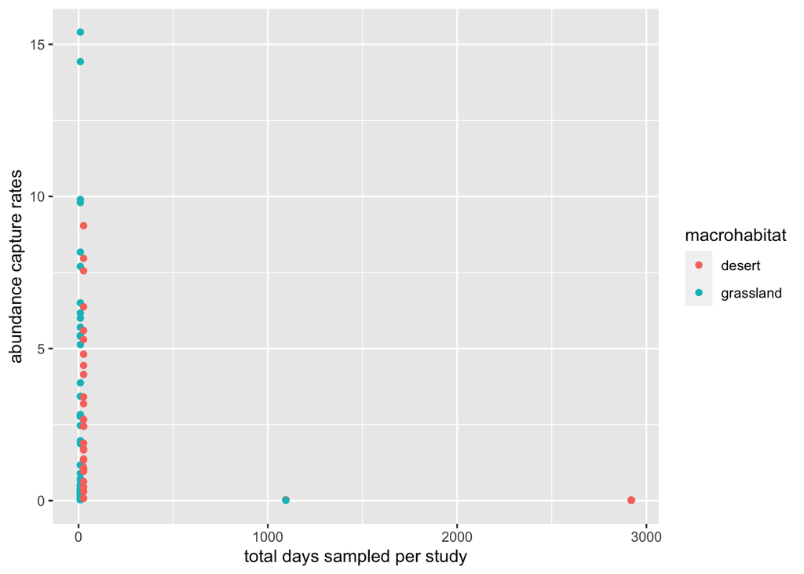

```r
#Sampling effort
ggplot(data_e1, aes(n_days, yi)) +
  geom_point(aes(color = macrohabitat)) +
  labs(x = "total days sampled per study", y = "abundance capture rates")
```

```r
MyData <- read.csv("MyData.csv")
```

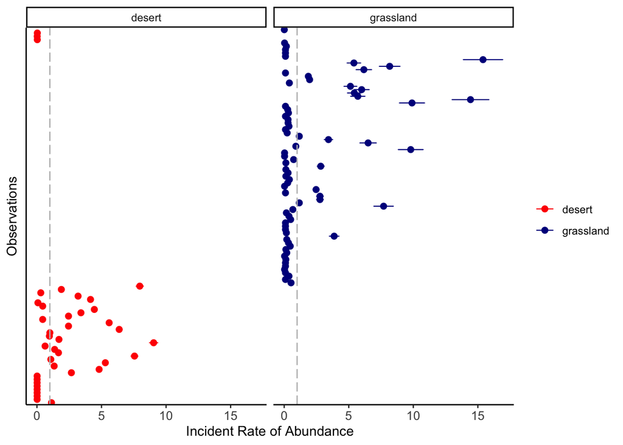

```r
###Forest Plot for paper
figure3 <- ggplot(data_all, aes(as.factor(rep), abundance_rate, color = macrohabitat)) +
  geom_point(size =2) +
  geom_errorbar(aes(ymin = abundance_rate - var_abundancerate, ymax = abundance_rate + var_abundancerate), size= 0.4, width=0.1, position = position_dodge(width = 0.5)) +
  coord_flip() +
  geom_hline(yintercept = 1, colour="grey", linetype = "longdash", size = 0.5) +
  labs(x = "Rep", y = "Incident Rate of Abundance") + theme_classic() +
  theme(axis.text.y = element_blank(), axis.ticks.y = element_blank(),legend.title = element_blank(), axis.text = element_text(size = 10)) + labs(x = "Observations") + scale_color_manual(values = c("desert" = "red", "grassland" = "dark blue")) + facet_wrap(~macrohabitat)

figure3
```

```r
gd <- data_all %>% group_by(macrohabitat) %>%
  summarise(abundance_rate = mean(abundance_rate), rep = rep/rep)
grassland <- gd[-c(1:39),]
desert <- gd[-c(40:113),]
```

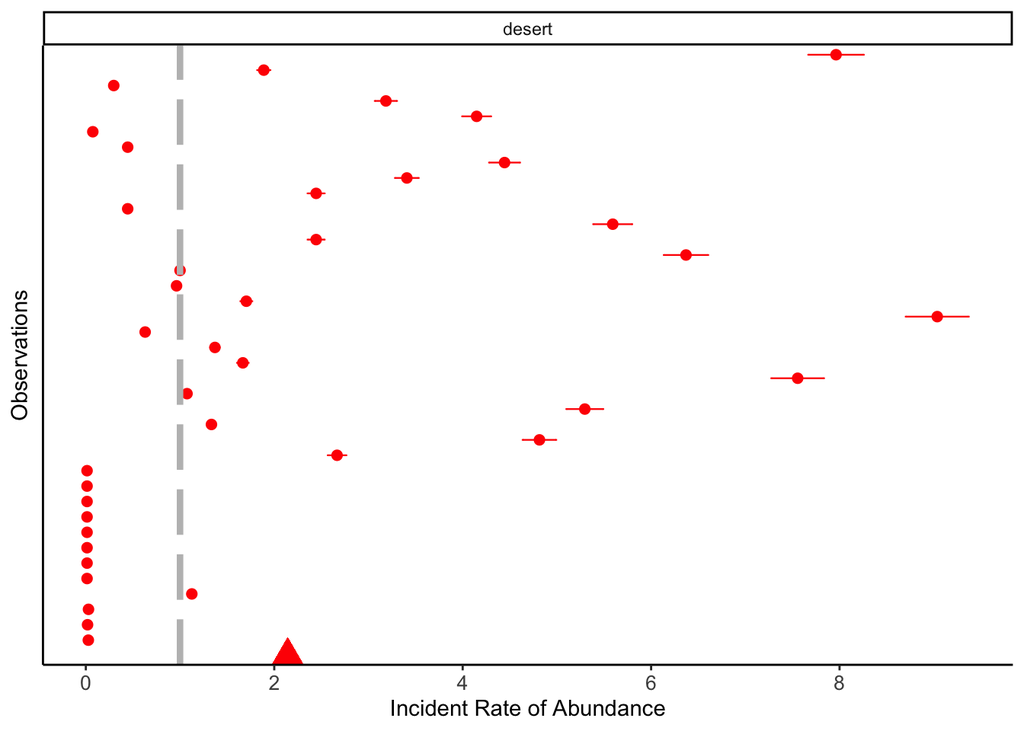

```r
desert.forest <- ggplot(subset(data_all, macrohabitat %in% c("desert")), aes(as.factor(rep), abundance_rate, color = macrohabitat)) +
  geom_point(size =2) +
  geom_errorbar(aes(ymin = abundance_rate - var_abundancerate, ymax = abundance_rate + var_abundancerate), size= 0.4, width=0.1, position = position_dodge(width = 0.5)) +
  coord_flip() + facet_wrap(~microsite, scales = "free") +
  geom_hline(yintercept = 1, colour="grey", linetype = "longdash", size = 1.5) +
  labs(x = "Rep", y = "Incident Rate of Abundance") + theme_classic() +
  theme(legend.position = "none", axis.text.y = element_blank(), axis.ticks.y = element_blank(),legend.title = element_blank(), axis.text = element_text(size = 10)) + labs(x = "Observations") + scale_color_manual(values = c("desert" = "red", "grassland" = "dark blue")) + facet_wrap(~macrohabitat, scales = "free") + geom_point(data = desert, size = 5, shape = "triangle")+scale_y_continuous(breaks=c(0,2,4,6,8))
desert.forest
```

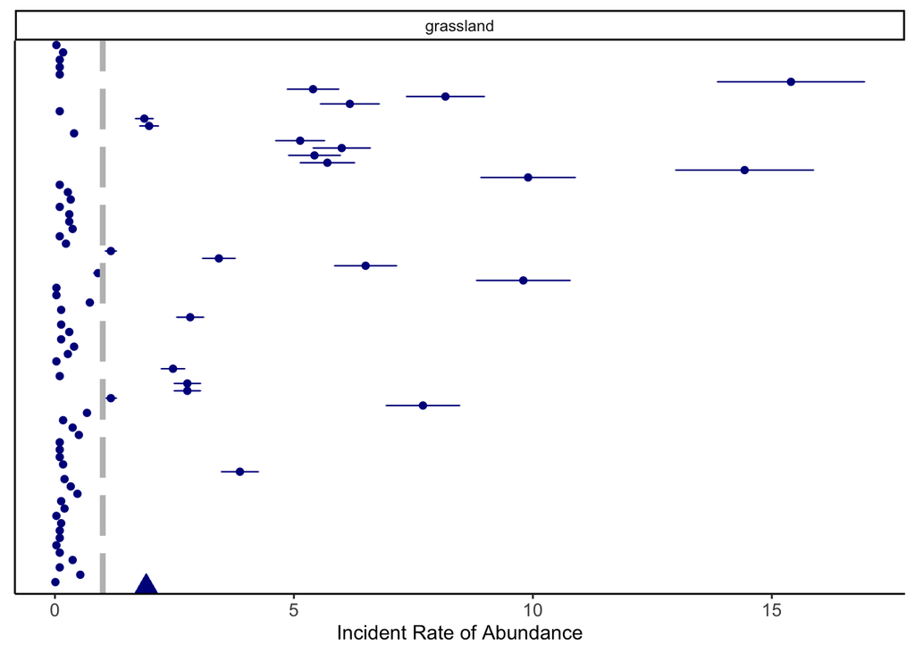

```r
grassland.forest <- ggplot(subset(data_all, macrohabitat %in% c("grassland")), aes(as.factor(rep), abundance_rate, color = macrohabitat)) +
  geom_point() +
  geom_errorbar(aes(ymin = abundance_rate - var_abundancerate, ymax = abundance_rate + var_abundancerate), size= 0.4, width=0.1, position = position_dodge(width = 0.5)) +
  coord_flip() + facet_wrap(~microsite, scales = "free") +
  geom_hline(yintercept = 1, colour="grey", linetype = "longdash", size = 1.5) +
  labs(x = "Rep", y = "Incident Rate of Abundance") + theme_classic() +
  theme(axis.title.y = element_blank(), axis.text.y = element_blank(), axis.ticks.y = element_blank(), legend.position = "none", legend.title = element_blank(), axis.text = element_text(size = 10)) + labs(x = "Observations") + scale_color_manual(values = c("desert" = "red", "grassland" = "dark blue")) + facet_wrap(~macrohabitat, scales = "free") + geom_point(data = grassland, size = 5, shape = "triangle")
grassland.forest
```

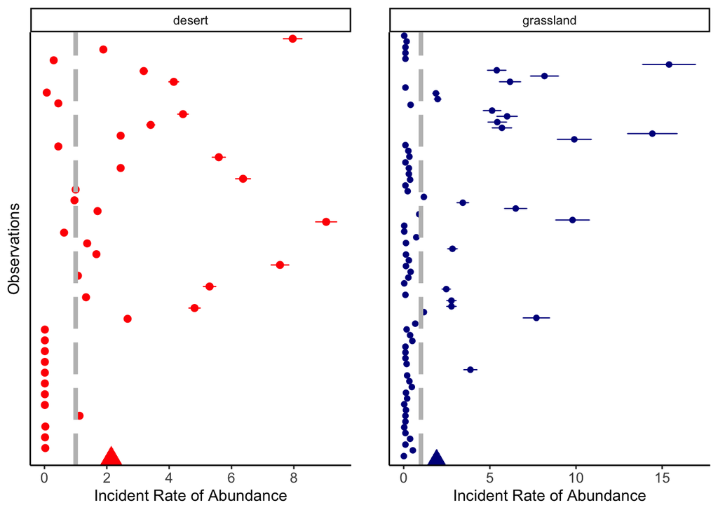

```r
###Figure is good! :D
forestfig <- ggarrange(desert.forest, grassland.forest, nrow = 1, align = "v", heights = 10)
forestfig
```

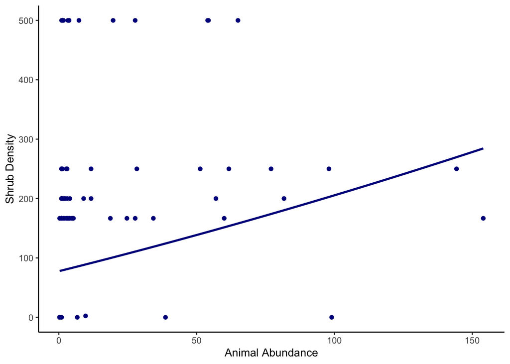

```r
### Has abundance on x axis so does not work!!!
grassland <- ggplot(subset(data_e1, macrohabitat %in% c("grassland")), aes(abundance, standardized.density, color = macrohabitat)) +
  geom_point() +
  geom_smooth(method = "lm", formula = y~x +I(x^2), mapping = aes(weight = n_days), se = F) + labs(x = "Animal Abundance", y = "Shrub Density") + theme_classic() + scale_color_manual(values = c("grassland" = "dark blue")) +theme(legend.position = "none")
grassland
```

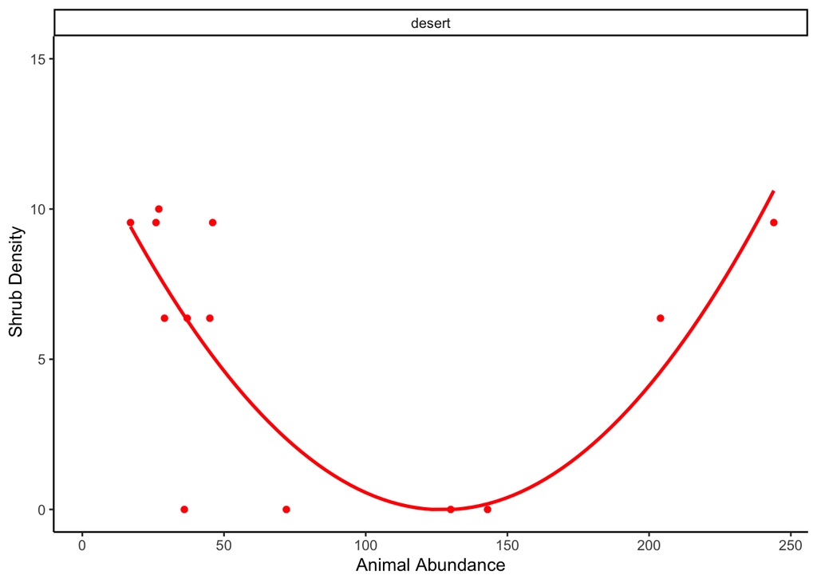

```r
### Has abundance on x axis so does not work!!!
desert <- ggplot(subset(data_e1, macrohabitat %in% c("desert")), aes(abundance, standardized.density, color = macrohabitat)) +
  geom_point() +
  geom_smooth(method = "lm", formula = y~x +I(x^2), mapping = aes(weight = n_days), se = F) + labs(x = "Animal Abundance", y = " Shrub Density") + theme_classic() + facet_wrap(~macrohabitat, scales = "free")+ scale_color_manual(values = c("desert" = "red", "grassland" = "dark blue")) + theme(legend.position = "none") + ylim(0,15)
desert
```

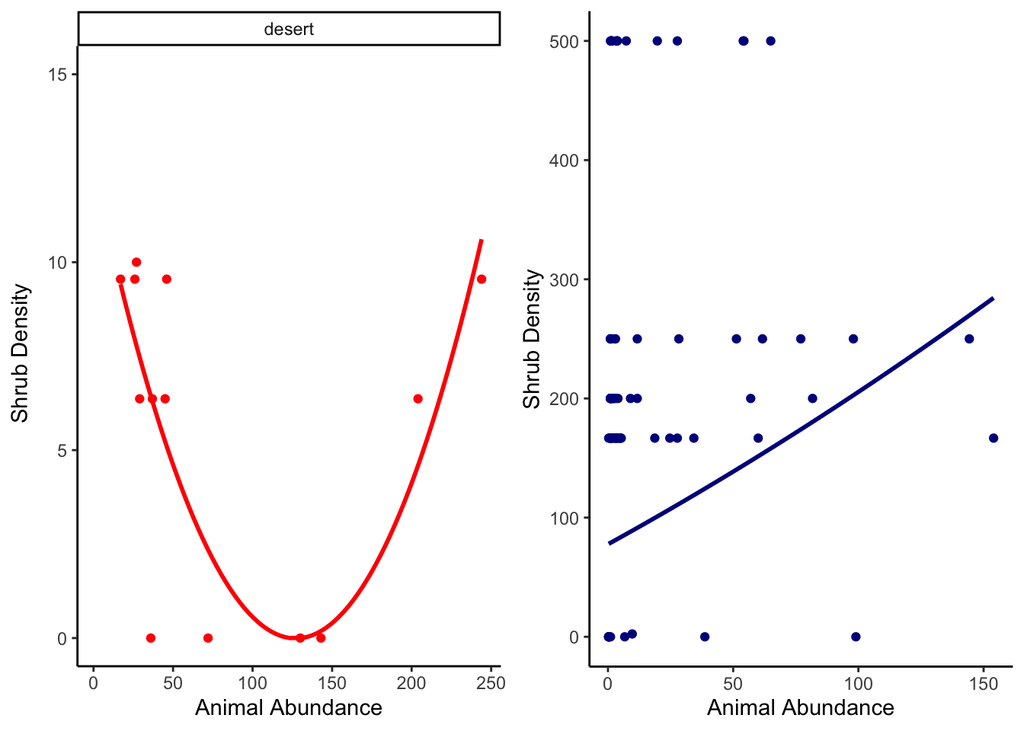

```r
scatterplot <- ggarrange(desert, grassland, nrow = 1, align = "v", heights = 10)
scatterplot
```

##Try with natural log (Do not use this!)

```r
data_1$natlog <- log(data_1$abundance)
log.grassland <- ggplot(subset(data_1, macrohabitat %in% c("grassland")), aes(standardized.density, natlog,  color = macrohabitat)) +
  geom_point() +
  geom_smooth(method = "lm", formula = y~x +I(x^2), mapping = aes(weight = n_days), se = F) + labs(x = "Shrub Density", y = "Log Animal Abundance") + theme_classic() + facet_wrap(~macrohabitat, scales = "free")+ scale_color_manual(values = c("desert" = "red", "grassland" = "dark blue")) +theme(legend.position = "none")

log.desert <- ggplot(subset(data_1, macrohabitat %in% c("desert")), aes(standardized.density, natlog, color = macrohabitat)) +
  geom_point() +
  geom_smooth(method = "lm", formula = y~x +I(x^2), mapping = aes(weight = n_days), se = F) + labs(x = "Shrub Density", y = "Log Animal Abundance") + theme_classic() + facet_wrap(~macrohabitat, scales = "free")+ scale_color_manual(values = c("desert" = "red", "grassland" = "dark blue")) + theme(legend.position = "none")
```

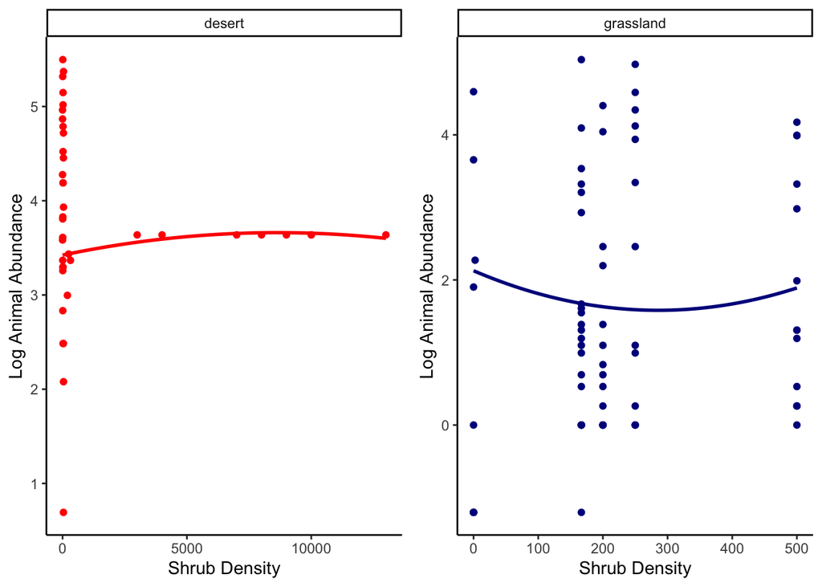

```r
logplot <- ggarrange(log.desert, log.grassland, nrow = 1, align = "v", heights = 10)
logplot
```

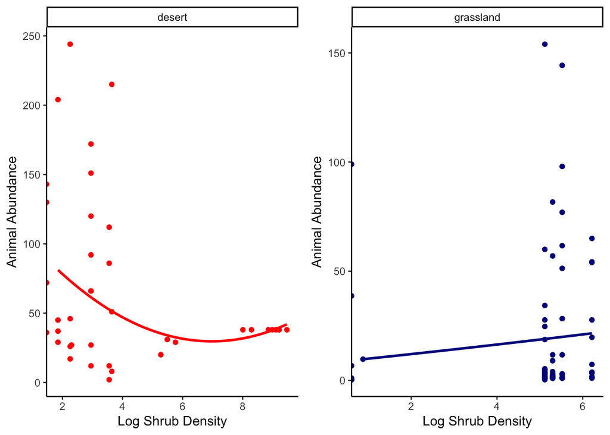

```r
data_1$natlog.dense <- log(data_1$standardized.density)
log.grassland.dense <- ggplot(subset(data_1, macrohabitat %in% c("grassland")), aes(natlog.dense, abundance,  color = macrohabitat)) +
  geom_point() +
  geom_smooth(method = "lm", formula = y~x +I(x^2), mapping = aes(weight = n_days), se = F) + labs(x = "Log Shrub Density", y = "Animal Abundance") + theme_classic() + facet_wrap(~macrohabitat, scales = "free")+ scale_color_manual(values = c("desert" = "red", "grassland" = "dark blue")) +theme(legend.position = "none")

log.desert.dense <- ggplot(subset(data_1, macrohabitat %in% c("desert")), aes(natlog.dense, abundance, color = macrohabitat)) +
  geom_point() +
  geom_smooth(method = "lm", formula = y~x +I(x^2), mapping = aes(weight = n_days), se = F) + labs(x = "Log Shrub Density", y = "Animal Abundance") + theme_classic() + facet_wrap(~macrohabitat, scales = "free")+ scale_color_manual(values = c("desert" = "red", "grassland" = "dark blue")) + theme(legend.position = "none")
logplot.dense <- ggarrange(log.desert.dense, log.grassland.dense, nrow = 1, align = "v", heights = 10)
logplot.dense
```

```r
Alex_paper <- read.csv("Carrizo_telemetry_with_shrub_density.csv")
Alex_paper_mean <- aggregate(Alex_paper[, 10], list(Alex_paper$year), mean)

Alex_paper_count <- Alex_paper %>%
 count(year, lizard)

library(dplyr)
Alex_paper_count <- Alex_paper_count %>%
  group_by(year) %>%
  summarise(Sum = sum(n))
colnames(Alex_paper_mean) <- c("year", "Average Density")

Alex_final <- merge(Alex_paper_mean, Alex_paper_count)

Test <- Alex_paper %>%
 count(lizard, year)
```

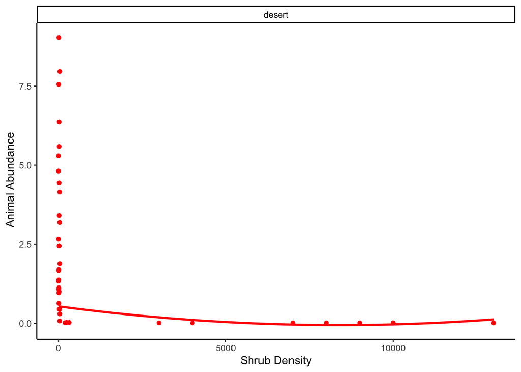

```r
###Figures have density on x axis
desertnew <- ggplot(subset(data_e1, macrohabitat %in% c("desert")), aes(standardized.density, yi, color = macrohabitat)) +
  geom_point() +
  geom_smooth(method = "lm", formula = y~x +I(x^2), mapping = aes(weight = n_days), se = F) + labs(x = "Shrub Density", y = " Animal Abundance") + theme_classic() + facet_wrap(~macrohabitat, scales = "free")+ scale_color_manual(values = c("desert" = "red", "grassland" = "dark blue")) + theme(legend.position = "none")
desertnew
```

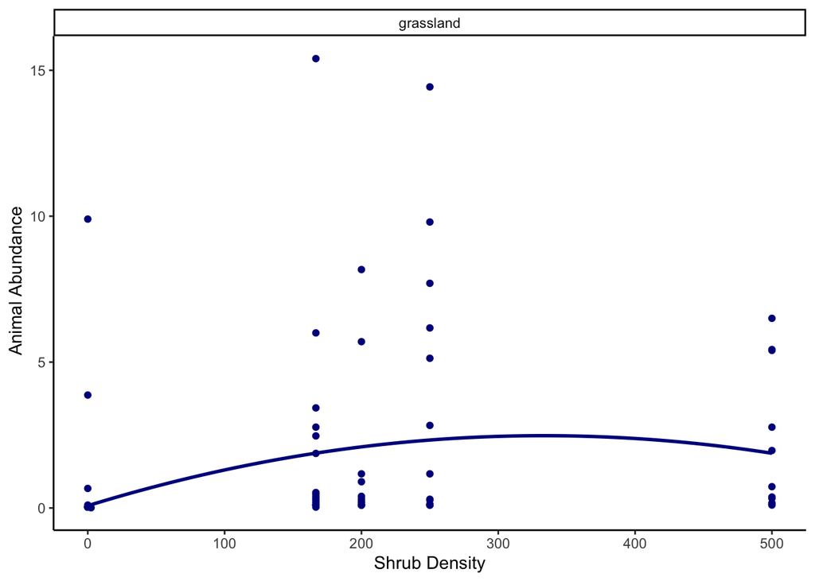

```r
grasslandnew <- ggplot(subset(data_e1, macrohabitat %in% c("grassland")), aes(standardized.density, yi, color = macrohabitat)) +
  geom_point() +
  geom_smooth(method = "lm", formula = y~x +I(x^2), mapping = aes(weight = n_days), se = F) + labs(x = "Shrub Density", y = " Animal Abundance") + theme_classic() + facet_wrap(~macrohabitat, scales = "free")+ scale_color_manual(values = c("desert" = "red", "grassland" = "dark blue")) + theme(legend.position = "none")
grasslandnew
```

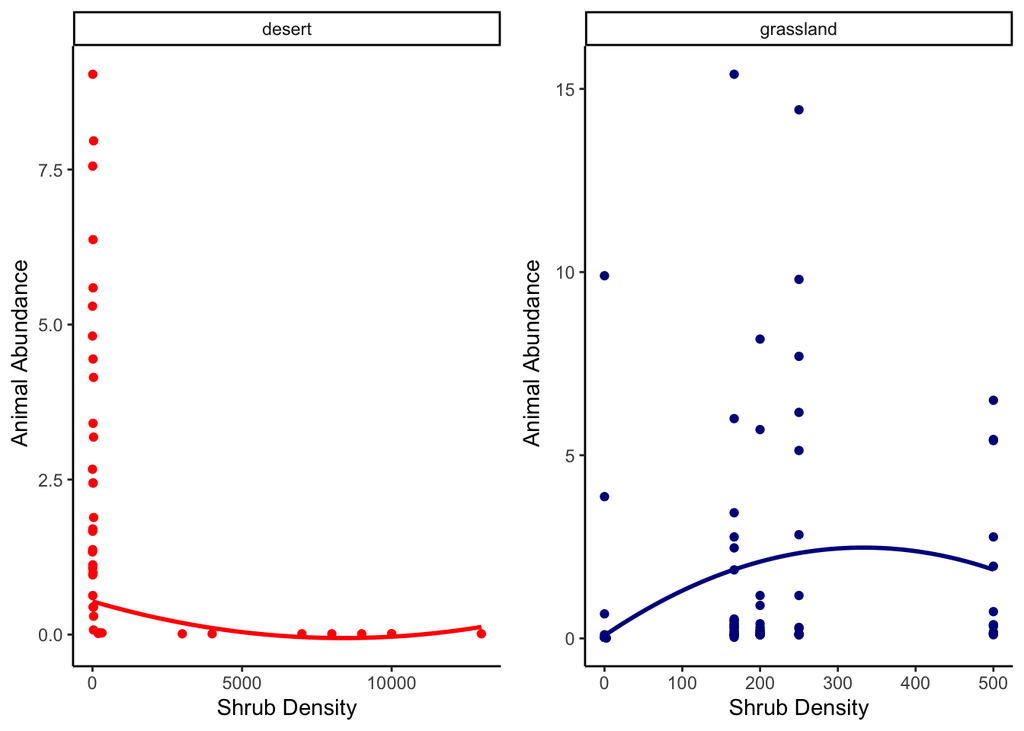

```r
scatterplotnew <- ggarrange(desertnew, grasslandnew, nrow = 1, align = "v", heights = 10)
scatterplotnew
```

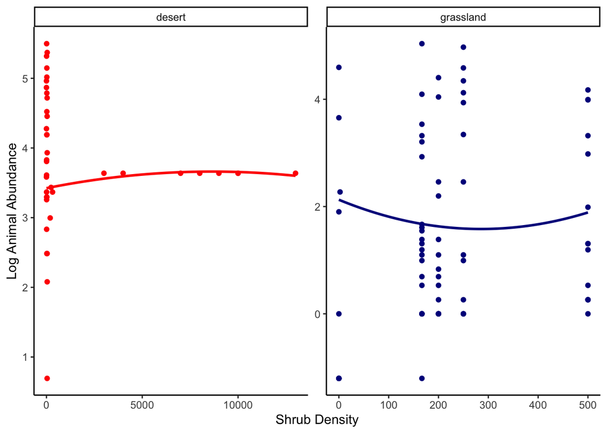

```r
log.facet <- ggplot(data_1, aes(standardized.density, natlog,  color = macrohabitat)) +
  geom_point() +
  geom_smooth(method = "lm", formula = y~x +I(x^2), mapping = aes(weight = n_days), se = F) + labs(x = "Shrub Density", y = "Log Animal Abundance") + theme_classic() + facet_wrap(~macrohabitat, scales = "free")+ scale_color_manual(values = c("desert" = "red", "grassland" = "dark blue")) +theme(legend.position = "none")
log.facet
```

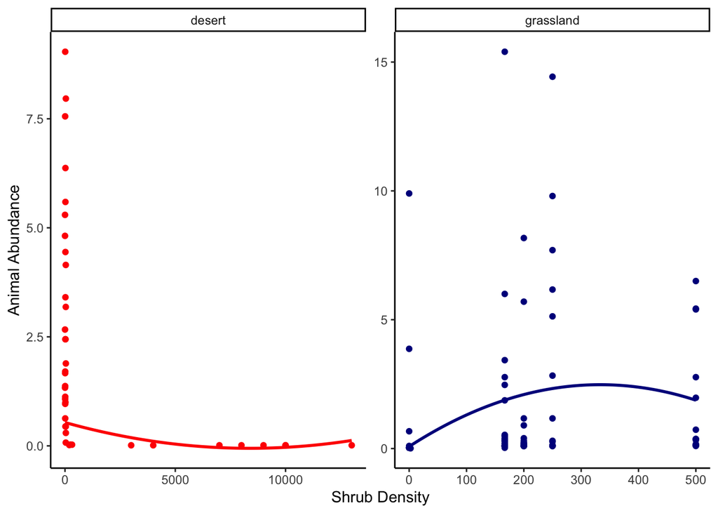

```r
plot <- ggplot(data_e1, aes(standardized.density, yi, color = macrohabitat)) +
  geom_point() +
  geom_smooth(method = "lm", formula = y~x +I(x^2), mapping = aes(weight = n_days), se = F) + labs(x = "Shrub Density", y = "Animal Abundance") + theme_classic() + facet_wrap(~macrohabitat, scales = "free")+ scale_color_manual(values = c("desert" = "red", "grassland" = "dark blue")) + theme(legend.position = "none")
plot
```

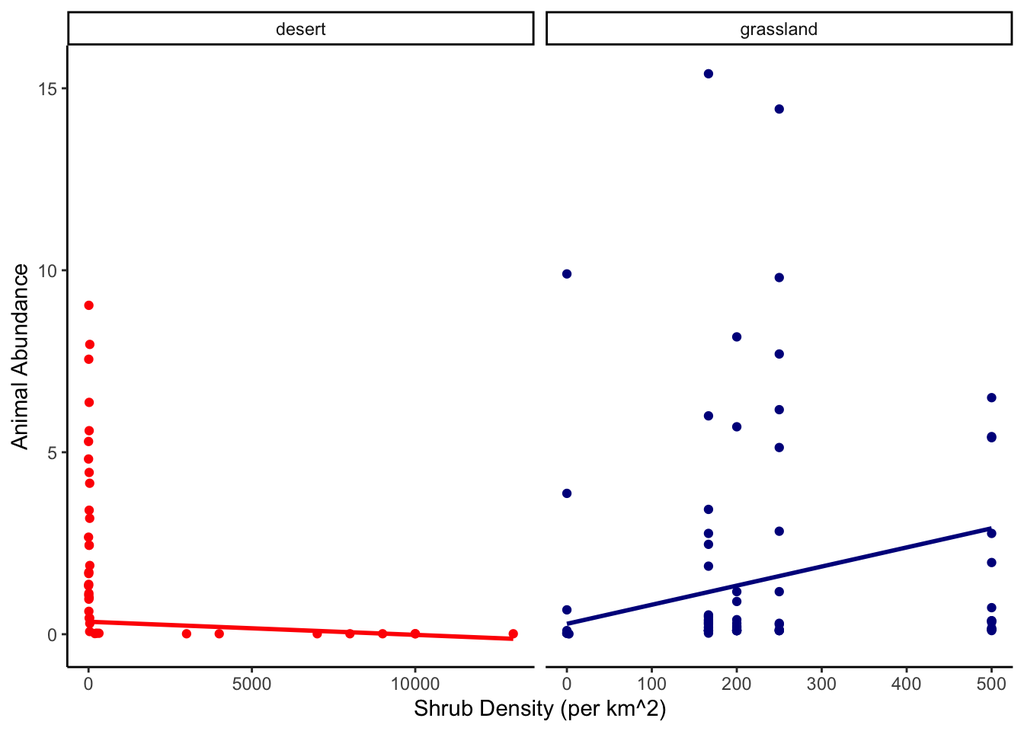

```r
###Main figure!
library(scales)
yi.plot <- ggplot(data_e1, aes(standardized.density, yi, color = macrohabitat)) +
  geom_point() +
  geom_smooth(method = "lm", formula = y~x, mapping = aes(weight = n_days), se = F) + labs(x = "Shrub Density (per km^2)", y = "Animal Abundance") + theme_classic() + facet_grid(~macrohabitat, scales = "free")+ scale_color_manual(values = c("desert" = "red", "grassland" = "dark blue")) + theme(legend.position = "none") +  scale_y_continuous(breaks= pretty_breaks())
yi.plot
```

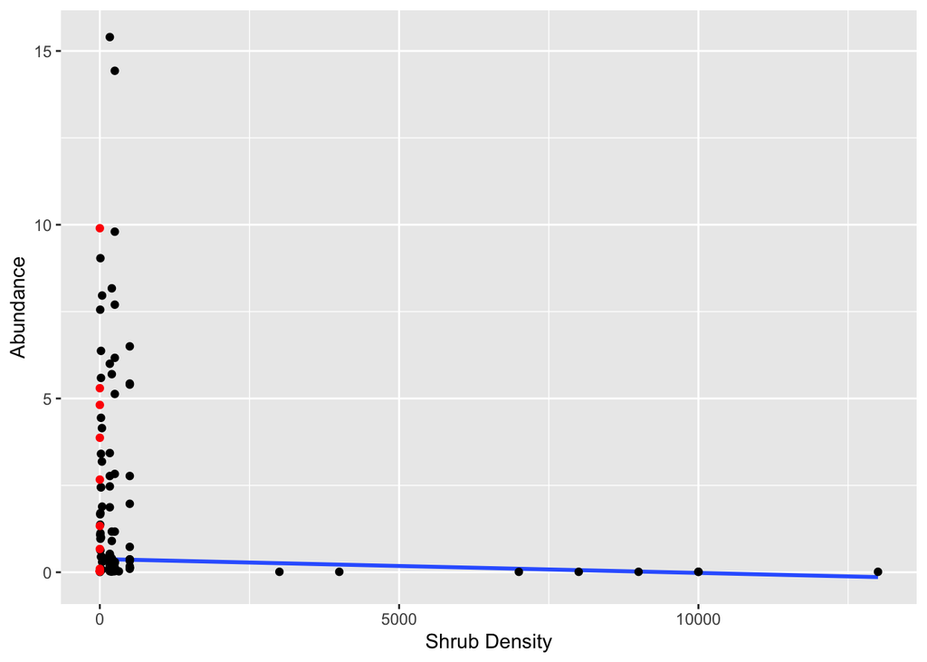

```r
####Testing main data with no zeros

exampleDF <- data_e1 %>%
  group_split(zeroes = standardized.density == 0 | yi == 0)

nozeros <- ggplot(exampleDF[[1]], aes(x = standardized.density, y = yi)) +
  geom_smooth(method = "lm", formula = y~x, mapping = aes(weight = n_days), se = F)  +
  geom_point() +
  geom_point(data = exampleDF[[2]], aes(x = standardized.density, y = yi), color = "red") +
  xlab("Shrub Density") +
  ylab("Abundance")
nozeros
```

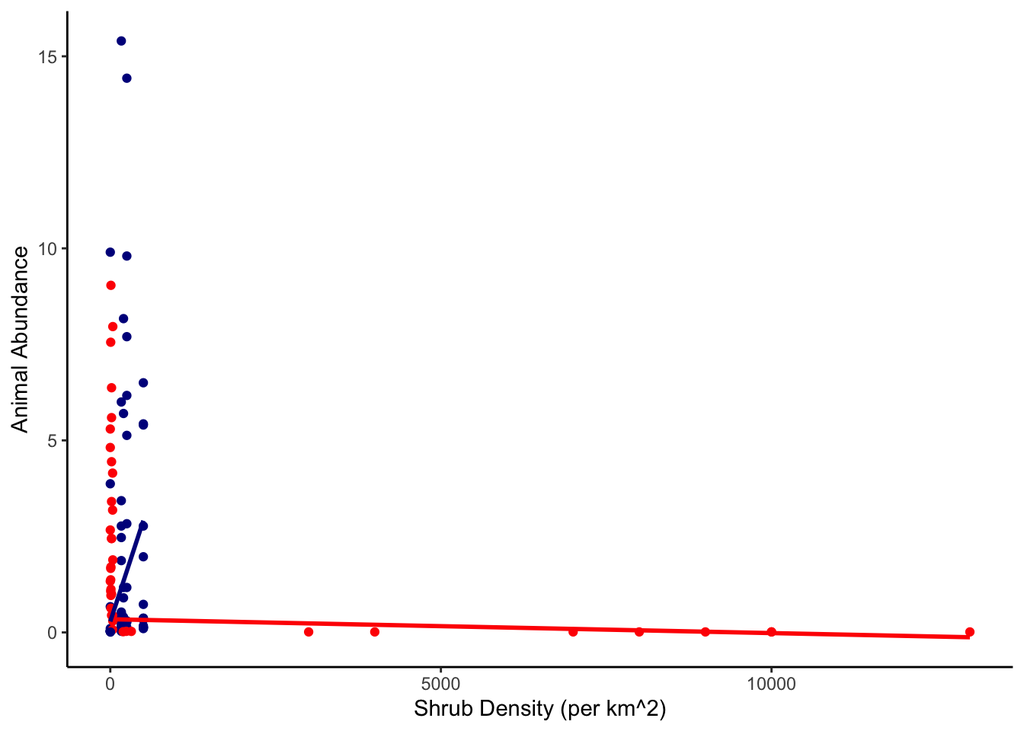

```r
yi.plot <- ggplot(data_e1, aes(standardized.density, yi, color = macrohabitat)) +
  geom_point() +
  geom_smooth(method = "lm", formula = y~x, mapping = aes(weight = n_days), se = F) + labs(x = "Shrub Density (per km^2)", y = "Animal Abundance") + theme_classic() + scale_color_manual(values = c("desert" = "red", "grassland" = "dark blue")) + theme(legend.position = "none")
yi.plot
```

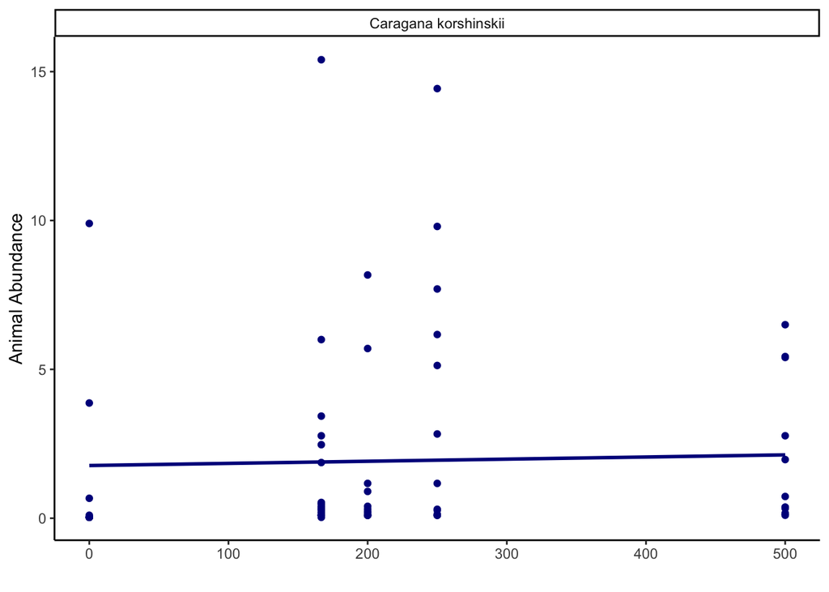

```r
data_new <- data_e1 %>% filter(plant.species !="Unknown")

Caragana.K <- ggplot(subset(data_new, plant.species %in% c("Caragana korshinskii")), aes( standardized.density, yi, color = plant.species)) +
  geom_point() +
  geom_smooth(method = "lm", formula = y~x, mapping = aes(weight = n_days), se = F) + labs(x = "", y = "Animal Abundance") + theme_classic() + facet_wrap(~plant.species) + scale_color_manual(values = c("Caragana korshinskii" = "dark blue")) + theme(legend.position = "none") +  scale_y_continuous(breaks= pretty_breaks())
Caragana.K
```